# Erstellung von POD-Plots für die Interessenfelder

Die Vorgehensweise ist folgendermaßen:

1. Zuerst werden alle Tracks geladen und ensprechend der höchsten Abkühlungsrate oder dem ersten Zeitpunkt mit einem Radarreflektivitätsfaktor von mehr als 35 dBZ sortiert.
2. Dann wird für alle Zeitschritte und Interessenfelder eine Statistik für einen 3x3-Pixelbereich um den Mittelpunkt des jeweiligen Ausschnittes für den Zeitpunkt berechnet.
3. Danach wird der Median oder, für die Indikatorsumme, das Maximum der Statistik daraufhin analysiert, ob es innerhalb des Schwellwertbereiches liegt. Wenn ja wird in eine neue Matrix an die entsprechende Stelle 1 eingetragen, wenn nicht 0.
4. Anschließend werden für alle Zeitpunkte und Felder die absolute Häufigkeit der Indikation ermittelt indem einfach alle Werte der Indikationsmatrix addiert werden.
5. Die relative Häufigkeit ist entsprechend die absolute Häufigkeit geteilt durch die Anzahl aller Indikationsmatrixzellen.
6. Danach wird die relative Häufigkeit für alle Zeitschritte aufsummiert um die kumulative Häufigkeit zu erhalten.
7. Zum Schluss wird das Ganze dargestellt.

## Nötige Pakete Laden

Zunächst müssen einige Pakete geladen werden, damit wir loslegen können.

```python
%matplotlib inline

import sys,os
import numpy as np
import datetime
from glob import glob

import matplotlib.pyplot as plt
import seaborn as sns

from standard_config import *

sys.path.append('/vols/talos/home/stephan/utils')
import trackdaten_laden

sys.path.append("/vols/talos/home/stephan/lib/citroPy")
import ci_config
```

## Funktionen definieren

Danach definieren wir einige Funktionen, um das Ganze etwas übersichtlicher zu gestalten.

Zunächst eine Funktion, um den Bereich um den Mittelpunkt einer gegebenen Matrix auszuschneiden:

```python
def ausschnitt(daten,nachbarschaft):
    datenvektor = daten.flatten()
    bereich = datenvektor[len(datenvektor)/2-(nachbarschaft**2/2):len(datenvektor)/2+(nachbarschaft**2/2)+1]
    bereich = np.reshape(bereich,(nachbarschaft,nachbarschaft))
    return bereich
```

Dann eine Funktion, um die zeitliche Abfolge der Trackdaten auf den ersten Zeitpunkt mit mehr als 35 dBZ zu zentrieren:

```python
def sort_radar(trackdaten,dt):
    rx_max = []

    for i in range(0,len(trackdaten['radar'])):
        radarmax = np.max(ausschnitt(trackdaten['radar'][i],9))
        rx_max.append(radarmax)

    # Index des ersten Zeitschrittes mit mehr als 35 dBZ finden
    try:
        sw_idx = np.min(np.where(np.array(rx_max)>35))

        zeit_nach = np.arange(0,len(trackdaten['radar'])-sw_idx)
        zeit_vor = np.arange(-sw_idx,0)

        rel_zeit = np.concatenate((zeit_vor,zeit_nach))

        return rel_zeit * dt
    except:
        return
```

Das Gleiche nochmal für die Zentrierung auf die höchste Abkühlrate:

```python
def sort_dtbmin(trackdaten,dt):
    dtb = []

    for i in range(1,len(trackdaten['ir108'])):
        dtb.append(np.median(ausschnitt(trackdaten['ir108'][i-1],3)-np.median(ausschnitt(trackdaten['ir108'][i],3))))

    # Index des ersten Zeitschrittes wo Differenz maximal wird, also die Ab-
    # kühlung am größten ist
    try:
        kuehl_idx = np.where(dtb == np.max(dtb))

        zeit_nach = np.arange(0,len(trackdaten['ir108'])-kuehl_idx[0])
        zeit_vor = np.arange(-kuehl_idx[0],0)

        rel_zeit = np.concatenate((zeit_vor,zeit_nach))

        return rel_zeit * dt
    except:
        return
```

Dann eine Funktion zur Berechnung von statistischen Größen für eine gegebene Nachbarschaft um den Mittelpunkt einer Matrix:

```python
def feldstatistik(felddaten,nachbarschaft):
    feld_min = []
    feld_q25 = []
    feld_med = []
    feld_mit = []
    feld_q75 = []
    feld_max = []

    for f in felddaten:
        feld_ausschnitt = ausschnitt(f,nachbarschaft)
        feld_min.append(np.min(feld_ausschnitt))
        feld_q25.append(np.percentile(feld_ausschnitt,25))
        feld_mit.append(np.median(feld_ausschnitt))
        feld_med.append(np.percentile(feld_ausschnitt,50))
        feld_q75.append(np.percentile(feld_ausschnitt,75))
        feld_max.append(np.max(feld_ausschnitt))

    ausgabe = {'min':feld_min,
               'q25':feld_q25,
               'med':feld_med,
               'mit':feld_mit,
               'q75':feld_q75,
               'max':feld_max}

    return ausgabe
```

Eine weitere Funktion, die prüft ob die Werte in einem gegebenen Datenvektor zwischen zwei gegebenen Schwellwerten liegt:

```python
def indikatorbewertung(daten,unterer_schwellwert,oberer_schwellwert):
    indiziert = [0 if i < unterer_schwellwert or i > oberer_schwellwert else 1 for i in daten]
    return indiziert
```

Und noch eine Funktion, die die Indikatorberwertung für einen gegebenen Zeitschritt zusammenbündelt:

```python
def indikator_zeitpunkt(zeiten,zeitpunkt,indikatordaten):
    ind = []

    zeit_idx = np.where(np.array(zeiten)==zeitpunkt)

    ind.append([indikatordaten[j] for j in zeit_idx[0].tolist()])

    return ind
```

## POD-Plots erstellen

Damit sollten wir in der Lage sein die POD-Plots zu erstellen.

Zunächst laden wir erstmal die Dateinamen aller NetCDF4-Dateien mit Trackdaten und sortieren sie aufsteigend.

```python
tracks = glob("/vols/talos/home/stephan/data/life_cycle/Handtracks/trackdata/*.nc")
tracks.sort()
```

Dann erstellen wir eine Liste mit den Namen der Interessenfelder, damit wir das nicht immer wieder eingeben müssen:

```python
analysefelder = ['b108',
    'b62_73',
    'indicator_sum',
    'cool_30',
    'cool_15',
    'b87_108',
    'db62_73_t15',
    'dtri_t15',
    'b62_108',
    'db62_73_t30',
    'db87_108_t15']
```

Jetzt erstellen wir eine Liste für die Zeitschritte und zwei Dictionarys für den Zeitpunkt der ersten Indikation und die Indikationsbewertung, in die wir dann die Ergebnisse packen:

```python
zeiten = []
erste_indikation = {key: [] for key in analysefelder}
indikatoren = {key: [] for key in analysefelder}
```

Jetzt fehlen uns noch die Schwellwerte. Die laden wir aus der Citro-Konfigurationsdatei:

```python
schwellwerte = ci_config.ci_thresholds
```

Nun laden wir die Daten für alle Tracks, zentrieren den Zeitablauf, berechnen für jeden Zeitschritt statistische Größen und führen die Indikationsbewertung durch:

```python
for tr in tracks:
        trackdaten = trackdaten_laden.trackdaten_laden(tr)

        #rel_zeit = sort_radar(trackdaten,5)
        rel_zeit = sort_dtbmin(trackdaten,5)


        # nur für alle Fälle, wo auch Z >= 35 dBZ erreicht werden
        if np.all(rel_zeit) != None:

            # sortierte Zeiten an Zeitliste anhängen
            zeiten.extend(rel_zeit)

            # alle Zeitschritte, wo Indikator gegriffen hat mit 1 eintragen
            for k in analysefelder:
                # Statistiken für das betrachtenden Felder berechnen
                stat = feldstatistik(trackdaten[k],3)

                # für die Indikatorsumme ist wohl nur das Maximum sinnvoll
                if k == 'indicator_sum':
                    ind = indikatorbewertung(stat['max'],7,10)
                    indikatoren[k].extend(ind)

                    ind_idx = np.where(np.array(ind)==1)

                    if ind_idx[0].size!=0:
                       erste_indikation[k].append(rel_zeit[np.min(ind_idx)])
                    else:
                       continue
                else:
                    ind = indikatorbewertung(stat['med'],schwellwerte[k][0],schwellwerte[k][1])
                    indikatoren[k].extend(ind)
                    ind_idx = np.where(np.array(ind)==1)

                    if ind_idx[0].size!=0:
                       erste_indikation[k].append(rel_zeit[np.min(ind_idx)])
                    else:
                       continue
        else:
            continue
```

[output not shown]

[output cut: 349 more lines]

[output not shown]

Da die Zeitschritte jetzt nur unsortiert aneinandergehängt sind, müssen wir die einzgartigen Zeitschrittwerte ermitteln, um dann für diese Werte die Indikationshäufigkeit ermitteln zu können.

```python
z = np.unique(zeiten)
print z
```

```
[-340 -335 -330 -325 -320 -315 -310 -305 -300 -295 -290 -285 -280 -275 -270
 -265 -260 -255 -250 -245 -240 -235 -230 -225 -220 -215 -210 -205 -200 -195
 -190 -185 -180 -175 -170 -165 -160 -155 -150 -145 -140 -135 -130 -125 -120
 -115 -110 -105 -100  -95  -90  -85  -80  -75  -70  -65  -60  -55  -50  -45
  -40  -35  -30  -25  -20  -15  -10   -5    0    5   10   15   20   25   30
   35   40   45   50   55   60   65   70   75   80   85   90   95  100  105
  110  115  120  125  130  135  140  145  150  155  160  165  170  175  180
  185  190  195  200  205  210  215  220]
```

Nun können wir die absolute und relative Indikationshäufigkeit ermitteln:

```python
abs_hfgk = {key: [] for key in analysefelder}
rel_hfgk = {key: [] for key in analysefelder}

for i in z:
    for k in analysefelder:
        ind = indikator_zeitpunkt(zeiten,i,indikatoren[k])
        ind_sum = float(np.sum(ind))

        ges_len = len(zeiten)
        abs_hfgk[k].append(ind_sum)
        rel_hfgk[k].append(ind_sum/ges_len)
```

Und die kumulative Häufigkeit:

```python
kum_hfgk = {key: [rel_hfgk[k][0]] for key in analysefelder}

for k in kum_hfgk:
    for i in range(1,len(rel_hfgk[k])):
        aktueller_wert = kum_hfgk[k][i-1] + rel_hfgk[k][i]
        kum_hfgk[k].append(aktueller_wert)
```

```python
legendenliste = {'b62_73':r'$\Delta T_\mathrm{B}(6,2\,\mu m;\,7,3\,\mu m)$',
                 'indicator_sum': 'Indikatorsumme',
                 'cool30':r'$T_\mathrm{B}(10,8\,\mu m), \Delta t = 30\,\mathrm{min}$',
                 'cool15':r'$T_\mathrm{B}(10,8\,\mu m), \Delta t = 15\,\mathrm{min}$',
                 'b87_108':r'$\Delta T_\mathrm{B}(8,7\,\mu m;\,10,8\,\mu m)$',
                 'db62_73_t15':r'$\Delta T_\mathrm{B}(6,2\,\mu m;\,7,3\,\mu m), \Delta t = 15\,\mathrm{min}$',
                 'dtri_t15':r'$\Delta \mathrm{tri}, \Delta t = 15\,\mathrm{min}$',
                 'b108':r'$T_\mathrm{B}(10,8\,\mu m)$',
                 'b62_108':r'$\Delta T_\mathrm{B}(6,2\,\mu m;\,10,8\,\mu m)$',
                 'db62_73_t30':r'$\Delta T_\mathrm{B}(6,2\,\mu m;\,7,3\,\mu m), \Delta t = 30\,\mathrm{min}$',
                 'db87_108_t15':r'$\Delta T_\mathrm{B}(8,7\,\mu m;\,10,8\,\mu m), \Delta t = 15\,\mathrm{min}$',
}
```

Nun die Abbildung:

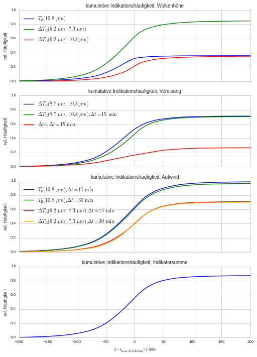

```python
#plt.switch_backend("Agg")
sns.set_style("whitegrid")
sns.set_context("paper")

f, axarr = plt.subplots(4, sharex=True,figsize=(8.27,11.69))
xlm = [-200,200]
axarr[0].plot(z,kum_hfgk['b108'],label = legendenliste['b108'],color='blue',linestyle='solid')
axarr[0].set_xlim(xlm)
axarr[0].set_ylim([0,1])
axarr[0].plot(z,kum_hfgk['b62_73'],color='green',linestyle='solid',label = legendenliste['b62_73'])
axarr[0].plot(z,kum_hfgk['b62_108'],color='red',linestyle='solid',label = legendenliste['b62_108'])
axarr[0].set_title(u"kumulative Indikationshäufigkeit, Wolkenhöhe")
axarr[0].set_ylabel(u"rel. Häufigkeit")
axarr[0].legend( loc=0,prop={'size':10})


axarr[1].plot(z,kum_hfgk['b87_108'],label = legendenliste['b87_108'],color='blue',linestyle='solid')
axarr[1].set_xlim(xlm)
axarr[1].set_ylim([0,1])
axarr[1].plot(z,kum_hfgk['db87_108_t15'],color='green',linestyle='solid',label = legendenliste['db87_108_t15'])
axarr[1].plot(z,kum_hfgk['dtri_t15'],color='red',linestyle='solid',label = legendenliste['dtri_t15'])
axarr[1].set_title(u"kumulative Indikationshäufigkeit, Vereisung")
axarr[1].set_ylabel(u"rel. Häufigkeit")
axarr[1].legend( loc=0,prop={'size':10})

axarr[2].plot(z,kum_hfgk['cool_15'],label = legendenliste['cool15'],color='blue',linestyle='solid')
axarr[2].set_xlim(xlm)
axarr[2].set_ylim([0,1])
axarr[2].plot(z,kum_hfgk['cool_30'],color='green',linestyle='solid',label = legendenliste['cool30'])
axarr[2].plot(z,kum_hfgk['db62_73_t15'],color='red',linestyle='solid',label = legendenliste['db62_73_t15'])
axarr[2].plot(z,kum_hfgk['db62_73_t30'],color='orange',linestyle='solid',label = legendenliste['db62_73_t30'])
axarr[2].set_title(u"kumulative Indikationshäufigkeit, Aufwind")
axarr[2].set_ylabel(u"rel. Häufigkeit")
axarr[2].legend( loc=0,prop={'size':10})

axarr[3].plot(z,kum_hfgk['indicator_sum'],color='blue',linestyle='solid')
axarr[3].set_xlim(xlm)
axarr[3].set_ylim([0,1])
axarr[3].set_title(u"kumulative Indikationshäufigkeit, Indikatorsumme")
axarr[3].set_ylabel(u"rel. Häufigkeit")
#axarr[3].set_xlabel(r"$(t-t_{35\,\mathrm{dBZ}})$ / min")
axarr[3].set_xlabel(r"$(t-t_{\mathrm{max. Abk\"{u}hlung}})$ / min")
```